# Analysis Script accompaning Affective Cognition paper

Desmond Ong

Updated: Mar 27, 2016

This markdown document contains code and analyses to accompany the following paper.

Ong, D. C., Zaki, J., & Goodman, N. D. (2015). Affective Cognition: Exploring lay theories of emotion. Cognition, 143, 141-162.

I have appended only the results sections of the paper, side-by-side with the corresponding analyses. The paper itself is much easier to read in the journal-formatted form, here: http://www.sciencedirect.com/science/article/pii/S0010027715300196

## Experiment 1 Results

Model selection (in Appendix A) revealed that participants’ emotion ratings were significantly predicted only by three of the seven regressors we initially proposed: amount won, the prediction error (PE), and the absolute value of the prediction error (|PE|) (see also Section 3.3 for a re-analysis with more data). Crucially, PE and |PE| account for significant variance in emotion ratings after accounting for amount won. This suggests that affective cognition is remarkably consistent with economic and psychological models of subjective utility. In particular, emotion inferences exhibited reference-dependence—tracking prediction error in addition to amount won—and loss aversion—in that emotion inferences were more strongly predicted by negative, as opposed to positive prediction error. These features suggest that lay observers spontaneously use key features of prospect theory ( Kahneman and Tversky, 1979 and Kahneman and Tversky, 1984) in reasoning about others’ emotions: a remarkable connection between formal and everyday theorizing. It is worth noting as well that the significant regressors for surprise followed a slightly different pattern from the rest of the other emotions, where the win probability, as well as regret and relief, seem just as important as the amount won, PE, and |PE|.

The aforementioned analysis suggests that amount won, PE, and |PE| are necessary to model emotion inferences in a gambling context and suggest a low dimensional structure for the situation features. Next, we explored the underlying dimensionality of participants’ inferences about agents’ emotions via an a priori planned Principal Component Analysis (PCA). Previous work on judgments of facial and verbal emotions (e.g., Russell, 1980 and Schlosberg, 1954) and self-reported emotions (e.g., Kuppens et al., 2012 and Watson and Tellegen, 1985) have suggested a low-dimensional structure, and we planned this analysis to see if a similar low-dimensional structure might emerge in attributed emotions in our paradigm.

The first principal component (PC) accounted for 59% of the variance in participants’ ratings along all 8 emotions, while the second PC accounted for 16%; subsequent PCs individually explained less than 10% of the variance. The first PC accounted for most of the variance in the emotion ratings, although the second PC accounted for a far lower, but still noteworthy, amount of variance. Full details of the PCA procedure and loading results are given in Appendix A.

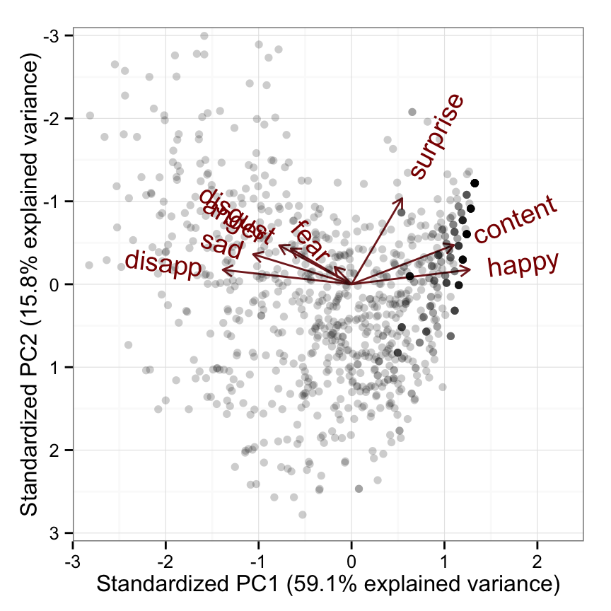

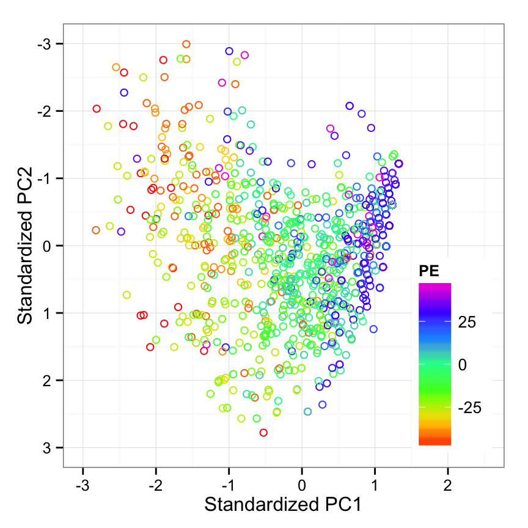

Figure 4: (A) Participants’ emotion ratings projected onto the dimensions of the first two principal components (PCs), along with the loadings of the PCs on each of the eight emotions. The loading of the PCs onto the eight emotions suggests a natural interpretation of the first two PCs as “valence” and “arousal” respectively. The labels for disgust and anger are overlapping. (B) Participant’s emotion ratings projected onto the dimensions of the first two PCs, this time colored by the prediction error (PE = amount won − expected value of wheel). (For interpretation of the references to colour in this figure legend, the reader is referred to the web version of this article.)

Together, these findings provide two key insights into the structure of affective cognition: (i) lay theories of emotion are low dimensional, consistent with affective science concepts of valence and arousal, and (ii) these core dimensions of emotion inference also track aspects of the situation and outcome that reflect value computation parameters described by economic models such as prospect theory. Although the specific structure of affective cognition likely varies depending on the complexity and details of a given context, we believe that observers’ use of low-dimensional “active psychological ingredients” in drawing inferences constitutes a core feature of affective cognition.

```
## Iteration number 1 out of 1
```

## Experiment 2 Results

Model-based posterior probabilities tightly tracked the observer judgments in Experiment 2 (Fig. 6B). The optimal noise parameter was 3.2 [2.9, 3.6], which resulted in a model RMSE of 0.116 [0.112, 0.120]. The model’s predictions explained much of the variance in participants’ judgments, achieving a high correlation of 0.806 [0.792, 0.819]. For comparison, the bootstrapped split-half correlation of the posterior probability estimates in Experiment 2 is 0.895 [0.866, 0.920]. The split-half correlation for the emotion attributions in Experiment 1, the data that this model is fit to, is 0.938 [0.925, 0.950]. Together these two split-half reliabilities give an upper-bound for model performance, and our model performs very comparably to these upper limits.

[figure not shown]

This results suggest that a Bayesian framework can accurately describe how observers make reverse inferences, P(o|e), given how they make forward inferences, P(e|o). At a broader level, the results imply that the causal knowledge in an observer’s lay theory of emotion is abstract enough to use for multiple patterns of reasoning. In the next section, we extend this work further by considering inferences about emotion from multiple sources of information.

# Cue Integration

```
## [1] 0.8619
```

```
## [1] 0.781
```

```
## [1] 0.7347
```

```
##
##  Paired t-test
##
## data:  posFaceAgg1$faceEntropy and negFaceAgg1$faceEntropy
## t = -2.7, df = 7, p-value = 0.03065
## alternative hypothesis: true difference in means is not equal to 0
## 95 percent confidence interval:
##  -1.9891 -0.1316
## sample estimates:
## mean of the differences
##                   -1.06
```

```
##
##  Paired t-test
##
## data:  posWheelAgg1$wheelEntropy and negWheelAgg1$wheelEntropy
## t = -4.1, df = 7, p-value = 0.004575
## alternative hypothesis: true difference in means is not equal to 0
## 95 percent confidence interval:
##  -0.6193 -0.1662
## sample estimates:
## mean of the differences
##                 -0.3927
```

```
##                 bayesCor                  faceCor                 wheelCor
##                   0.8125                   0.7333                   0.6916
##     negFacePosWheelBayes      negFacePosWheelFace     negFacePosWheelWheel
##                   0.5705                   0.3428                   0.4647
##     posFaceNegWheelBayes      posFaceNegWheelFace     posFaceNegWheelWheel
##                   0.6665                   0.6784                   0.2972
##                rmseBayes                 rmseFace                rmseWheel
##                   1.2176                   1.3857                   1.5244
## rmseNegFacePosWheelBayes  rmseNegFacePosWheelFace rmseNegFacePosWheelWheel
##                   1.6900                   1.8346                   2.2972
## rmsePosFaceNegWheelBayes  rmsePosFaceNegWheelFace rmsePosFaceNegWheelWheel
##                   1.4955                   1.8735                   2.0579
```

```
##                 bayesCor                  faceCor                 wheelCor
##                   0.7902                   0.7055                   0.6636
##     negFacePosWheelBayes      negFacePosWheelFace     negFacePosWheelWheel
##                   0.4538                   0.2134                   0.3320
##     posFaceNegWheelBayes      posFaceNegWheelFace     posFaceNegWheelWheel
##                   0.5683                   0.5509                   0.1649
##                rmseBayes                 rmseFace                rmseWheel
##                   1.1490                   1.3144                   1.4622
## rmseNegFacePosWheelBayes  rmseNegFacePosWheelFace rmseNegFacePosWheelWheel
##                   1.4906                   1.6058                   2.1023
## rmsePosFaceNegWheelBayes  rmsePosFaceNegWheelFace rmsePosFaceNegWheelWheel
##                   1.2888                   1.5842                   1.8283
```

```
##                 bayesCor                  faceCor                 wheelCor
##                   0.8333                   0.7585                   0.7171
##     negFacePosWheelBayes      negFacePosWheelFace     negFacePosWheelWheel
##                   0.6681                   0.4682                   0.5757
##     posFaceNegWheelBayes      posFaceNegWheelFace     posFaceNegWheelWheel
##                   0.7477                   0.7779                   0.4223
##                rmseBayes                 rmseFace                rmseWheel
##                   1.2871                   1.4642                   1.5893
## rmseNegFacePosWheelBayes  rmseNegFacePosWheelFace rmseNegFacePosWheelWheel
##                   1.9153                   2.0874                   2.5122
## rmsePosFaceNegWheelBayes  rmsePosFaceNegWheelFace rmsePosFaceNegWheelWheel
##                   1.7326                   2.2060                   2.3008
```

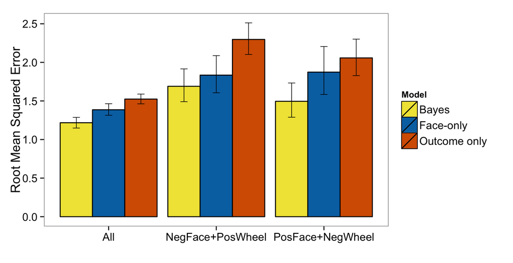

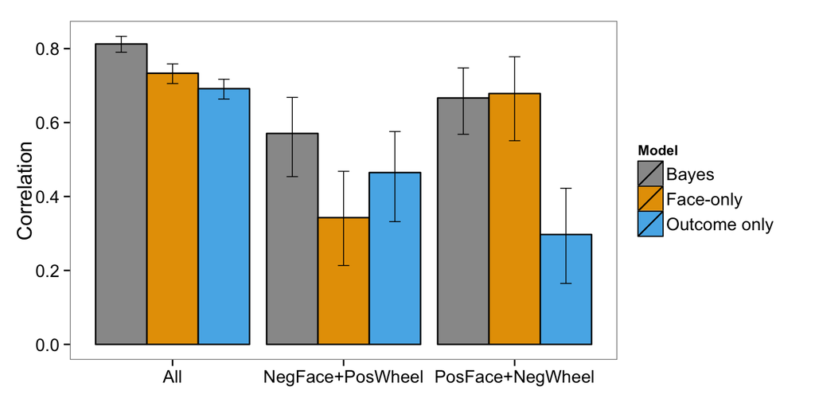

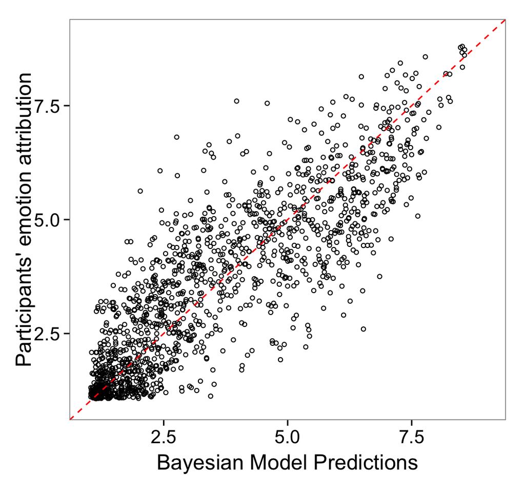

```
## [1] 0.8097
```

```
## [1] 0.6385
```

```
## [1] 0.7241
```

```
##
##  Paired t-test
##
## data:  posWheelAgg1$wheelEntropy and negWheelAgg1$wheelEntropy
## t = -5.009, df = 7, p-value = 0.001549
## alternative hypothesis: true difference in means is not equal to 0
## 95 percent confidence interval:
##  -0.5868 -0.2105
## sample estimates:
## mean of the differences
##                 -0.3986
```

```
##
##  Paired t-test
##
## data:  posFaceAgg1$faceEntropy and negFaceAgg1$faceEntropy
## t = -2.832, df = 7, p-value = 0.02532
## alternative hypothesis: true difference in means is not equal to 0
## 95 percent confidence interval:
##  -1.6875 -0.1519
## sample estimates:
## mean of the differences
##                 -0.9197
```

```
## [1] 2.8
```

```
## [1] 1.804
```

```
## [1] 6.975
```

```
## [1] 2.626
```

```
## [1] 6.5
```

```
## [1] 3.786
```

```
##                 bayesCor             utteranceCor                 wheelCor
##                   0.7326                   0.5702                   0.6685
##     negFacePosWheelBayes      negFacePosWheelFace     negFacePosWheelWheel
##                   0.7842                  -0.1470                   0.7752
##     posFaceNegWheelBayes      posFaceNegWheelFace     posFaceNegWheelWheel
##                   0.5166                   0.3985                   0.4856
##                rmseBayes                 rmseFace                rmseWheel
##                   1.4940                   1.8475                   1.6193
## rmseNegFacePosWheelBayes  rmseNegFacePosWheelFace rmseNegFacePosWheelWheel
##                   1.4402                   2.9079                   1.6548
## rmsePosFaceNegWheelBayes  rmsePosFaceNegWheelFace rmsePosFaceNegWheelWheel
##                   1.7947                   2.4849                   1.7458
```

```
##                 bayesCor             utteranceCor                 wheelCor
##                   0.6870                   0.5177                   0.6231
##     negFacePosWheelBayes      negFacePosWheelFace     negFacePosWheelWheel
##                   0.7022                  -0.2762                   0.6838
##     posFaceNegWheelBayes      posFaceNegWheelFace     posFaceNegWheelWheel
##                   0.3665                   0.2450                   0.3214
##                rmseBayes                 rmseFace                rmseWheel
##                   1.3912                   1.7308                   1.5213
## rmseNegFacePosWheelBayes  rmseNegFacePosWheelFace rmseNegFacePosWheelWheel
##                   1.2477                   2.5693                   1.4174
## rmsePosFaceNegWheelBayes  rmsePosFaceNegWheelFace rmsePosFaceNegWheelWheel
##                   1.5719                   2.1880                   1.4522
```

```
##                 bayesCor             utteranceCor                 wheelCor
##                  0.76965                  0.61801                  0.70987
##     negFacePosWheelBayes      negFacePosWheelFace     negFacePosWheelWheel
##                  0.84494                 -0.01233                  0.84398
##     posFaceNegWheelBayes      posFaceNegWheelFace     posFaceNegWheelWheel
##                  0.61959                  0.53193                  0.62844
##                rmseBayes                 rmseFace                rmseWheel
##                  1.61206                  1.96858                  1.72354
## rmseNegFacePosWheelBayes  rmseNegFacePosWheelFace rmseNegFacePosWheelWheel
##                  1.65683                  3.24052                  1.92477
## rmsePosFaceNegWheelBayes  rmsePosFaceNegWheelFace rmsePosFaceNegWheelWheel
##                  2.05869                  2.78860                  2.06391
```

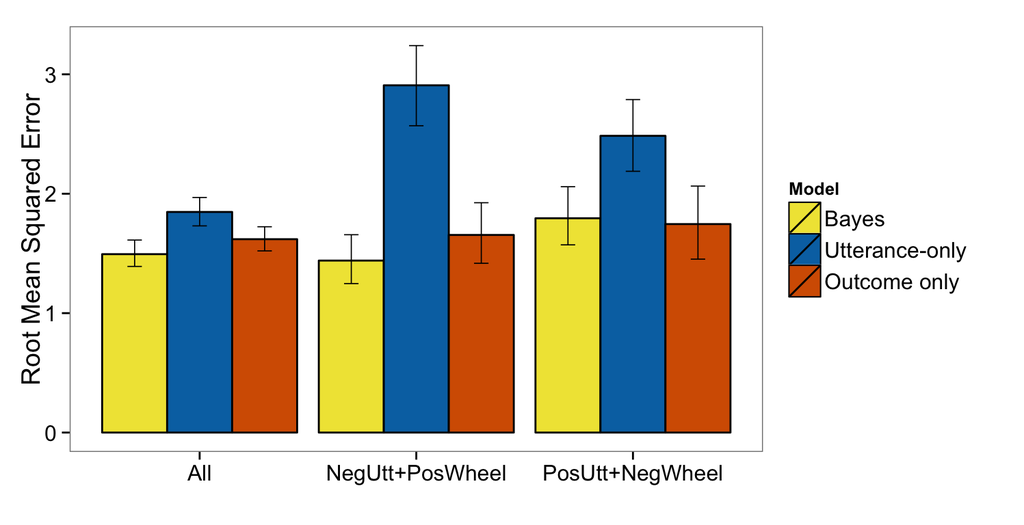

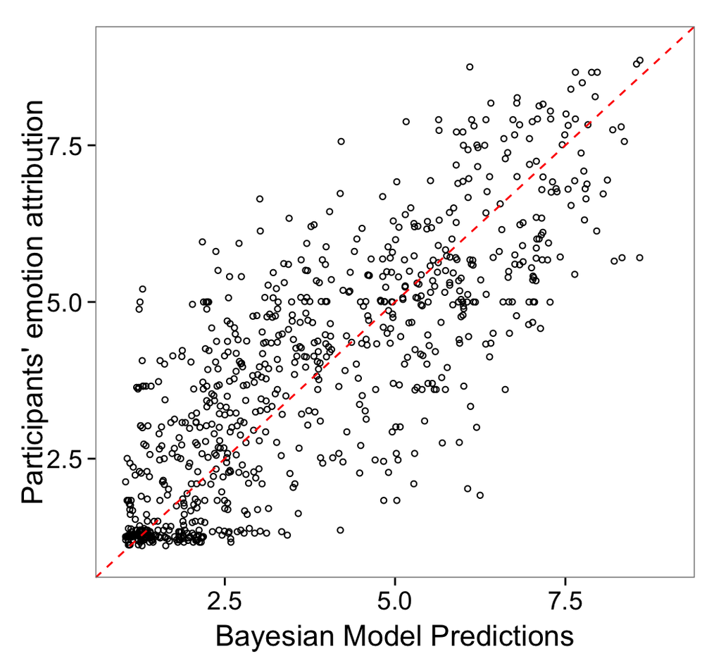

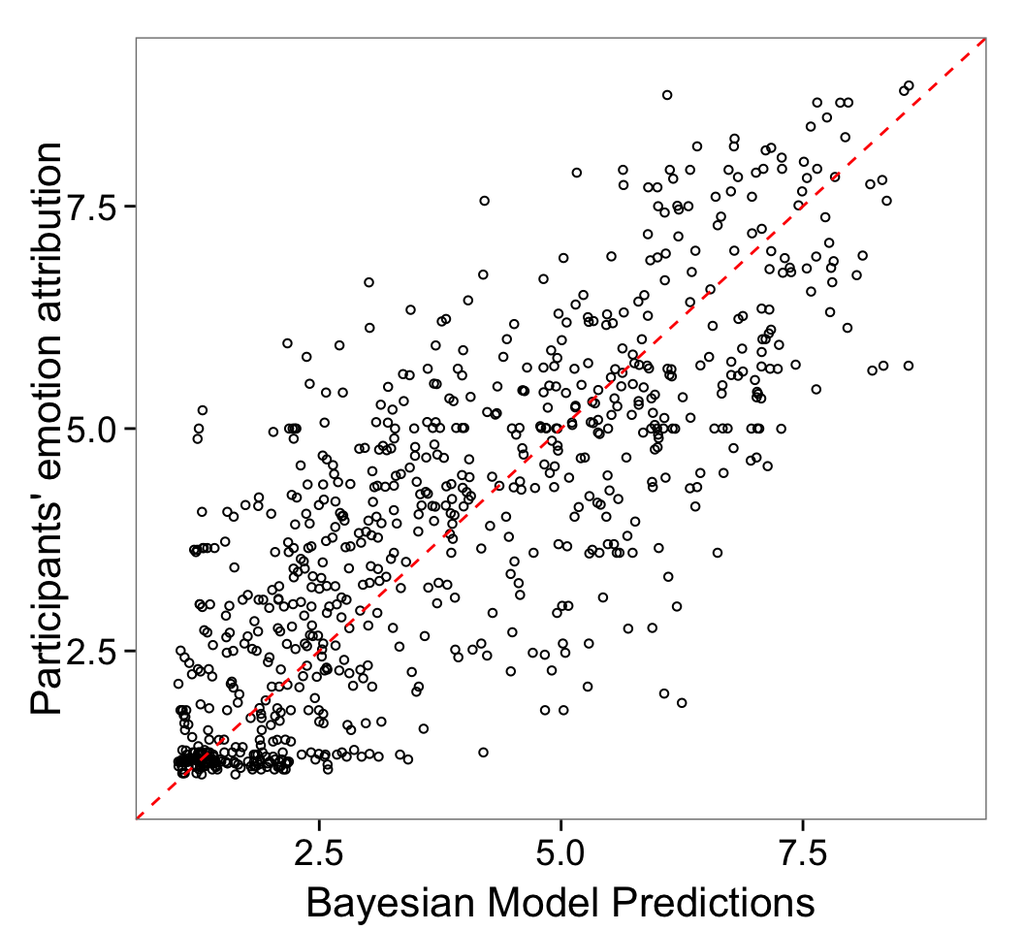

Figure 11

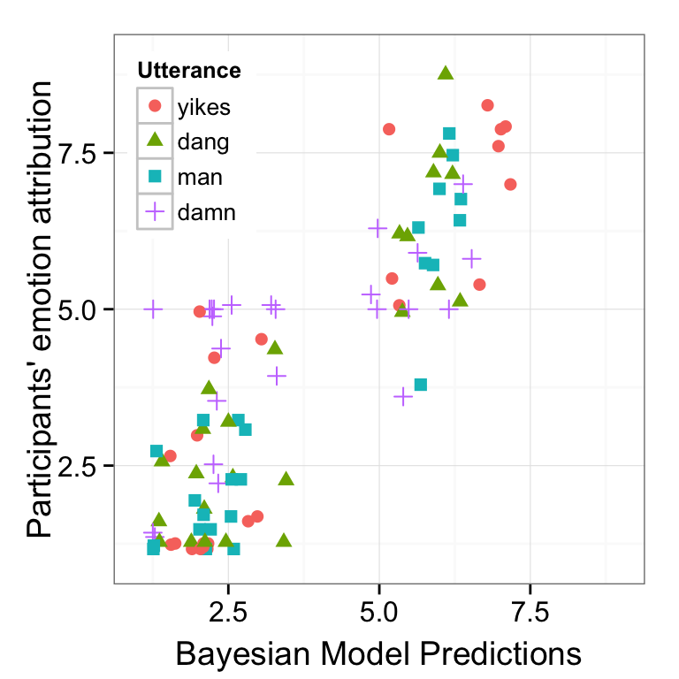

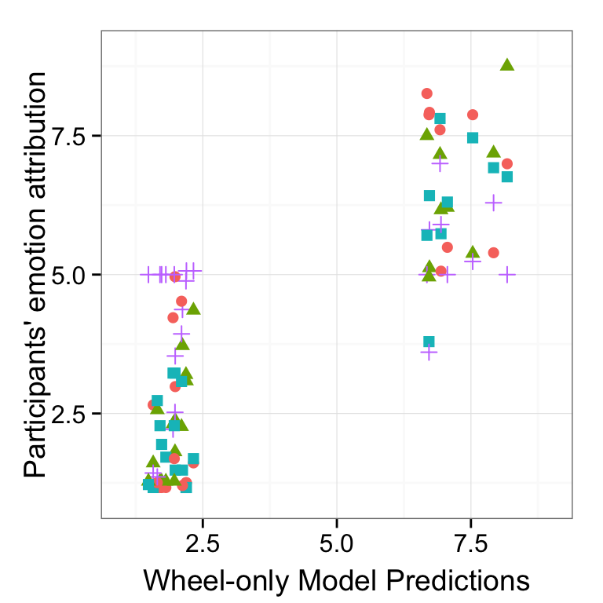

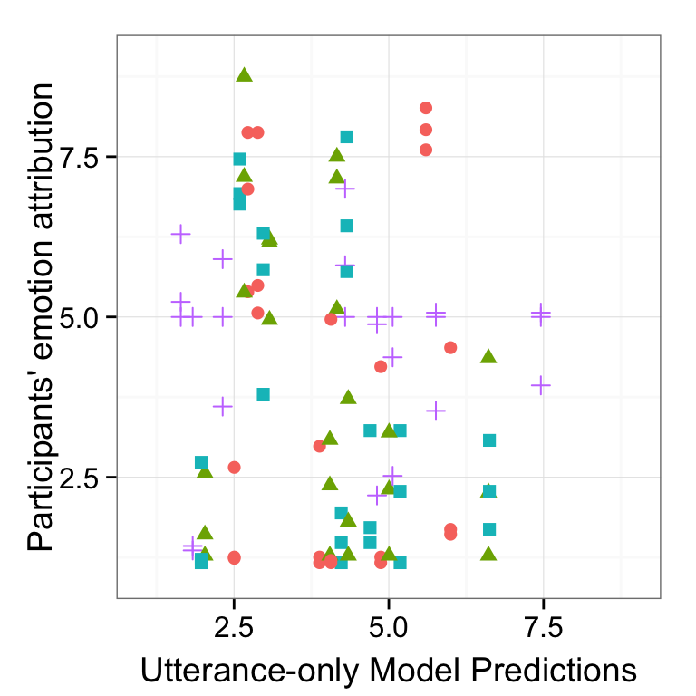

Figure 12

```
## Linear mixed model fit by REML ['merModLmerTest']
## Formula: happy ~ win + PE + absPE + affectiveCloseness + (1 | workerid)
##    Data: expt1_data
##
## REML criterion at convergence: 3503
##
## Random effects:
##  Groups   Name        Variance Std.Dev.
##  workerid (Intercept) 0.556    0.745
##  Residual             1.594    1.262
## Number of obs: 1000, groups: workerid, 100
##
## Fixed effects:
##                     Estimate Std. Error        df t value Pr(>|t|)
## (Intercept)         4.50e+00   2.09e-01  9.31e+02   21.55  < 2e-16 ***
## win                 3.88e-02   3.32e-03  9.22e+02   11.68  < 2e-16 ***
## PE                  3.52e-02   3.45e-03  9.24e+02   10.20  < 2e-16 ***
## absPE              -1.75e-02   2.94e-03  9.32e+02   -5.95  3.9e-09 ***
## affectiveCloseness -1.61e-05   1.33e-05  9.34e+02   -1.22     0.22
## ---
## Signif. codes:  0 '***' 0.001 '**' 0.01 '*' 0.05 '.' 0.1 ' ' 1
##
## Correlation of Fixed Effects:
##             (Intr) win    PE     absPE
## win         -0.859
## PE           0.768 -0.887
## absPE       -0.390  0.090 -0.107
## affctvClsns  0.041 -0.040 -0.043 -0.059
```

```
## Linear mixed model fit by REML ['merModLmerTest']
## Formula: happy ~ win + PE + absPE + Regret + Relief + lwinProb + affectiveCloseness +      (1 | spinnerID) + (1 | workerid) + (1 | expt)
##    Data: meta_full
##
## REML criterion at convergence: 10703
##
## Random effects:
##  Groups    Name        Variance Std.Dev.
##  workerid  (Intercept) 0.42076  0.6487
##  spinnerID (Intercept) 0.19580  0.4425
##  expt      (Intercept) 0.00575  0.0758
##  Residual              1.58904  1.2606
## Number of obs: 3048, groups: workerid, 690; spinnerID, 50; expt, 3
##
## Fixed effects:
##                     Estimate Std. Error        df t value Pr(>|t|)
## (Intercept)         4.39e+00   6.90e-01  4.70e+01    6.36  7.3e-08 ***
## win                 3.56e-02   7.02e-03  4.70e+01    5.08  6.5e-06 ***
## PE                  2.12e-02   1.24e-02  4.80e+01    1.71   0.0937 .
## absPE              -1.69e-02   5.83e-03  4.80e+01   -2.90   0.0057 **
## Regret              1.26e-02   1.04e-02  4.30e+01    1.21   0.2333
## Relief              6.73e-03   8.42e-03  4.40e+01    0.80   0.4282
## lwinProb           -3.24e-01   2.55e-01  5.00e+01   -1.27   0.2107
## affectiveCloseness -3.31e-05   1.12e-05  2.74e+03   -2.96   0.0031 **
## ---
## Signif. codes:  0 '***' 0.001 '**' 0.01 '*' 0.05 '.' 0.1 ' ' 1
##
## Correlation of Fixed Effects:
##             (Intr) win    PE     absPE  Regret Relief lwnPrb
## win         -0.782
## PE          -0.125  0.077
## absPE        0.051  0.056  0.068
## Regret       0.734 -0.574 -0.661  0.112
## Relief      -0.055 -0.222 -0.710 -0.325  0.241
## lwinProb     0.468 -0.080  0.035  0.236  0.089 -0.026
## affctvClsns  0.009 -0.015 -0.004 -0.024 -0.001 -0.010 -0.010
```

```
## Linear mixed model fit by REML ['merModLmerTest']
## Formula: sad ~ win + PE + absPE + Regret + Relief + lwinProb + affectiveCloseness +      (1 | spinnerID) + (1 | workerid) + (1 | expt)
##    Data: meta_full
##
## REML criterion at convergence: 11417
##
## Random effects:
##  Groups    Name        Variance Std.Dev.
##  workerid  (Intercept) 0.721643 0.8495
##  spinnerID (Intercept) 0.252618 0.5026
##  expt      (Intercept) 0.000585 0.0242
##  Residual              1.926566 1.3880
## Number of obs: 3048, groups: workerid, 690; spinnerID, 50; expt, 3
##
## Fixed effects:
##                     Estimate Std. Error        df t value Pr(>|t|)
## (Intercept)         3.72e+00   7.78e-01  4.80e+01    4.79  1.6e-05 ***
## win                -2.72e-02   7.92e-03  4.80e+01   -3.44   0.0012 **
## PE                 -1.41e-02   1.40e-02  5.00e+01   -1.01   0.3175
## absPE               2.83e-02   6.57e-03  4.90e+01    4.30  8.1e-05 ***
## Regret             -3.80e-03   1.18e-02  4.50e+01   -0.32   0.7490
## Relief             -3.87e-03   9.51e-03  4.50e+01   -0.41   0.6860
## lwinProb            1.86e-01   2.88e-01  5.10e+01    0.65   0.5214
## affectiveCloseness  4.37e-06   1.24e-05  2.67e+03    0.35   0.7251
## ---
## Signif. codes:  0 '***' 0.001 '**' 0.01 '*' 0.05 '.' 0.1 ' ' 1
##
## Correlation of Fixed Effects:
##             (Intr) win    PE     absPE  Regret Relief lwnPrb
## win         -0.783
## PE          -0.127  0.078
## absPE        0.053  0.055  0.068
## Regret       0.736 -0.575 -0.661  0.114
## Relief      -0.055 -0.223 -0.710 -0.325  0.239
## lwinProb     0.468 -0.080  0.034  0.236  0.090 -0.025
## affctvClsns  0.009 -0.015 -0.004 -0.024 -0.001 -0.010 -0.009
```

```
## Linear mixed model fit by REML ['merModLmerTest']
## Formula: happy ~ win + PE + absPE + Regret + Relief + lwinProb + affectiveCloseness +      (1 | workerid) + (1 | spinnerID) + (1 | expt)
##    Data: meta_full
##
## REML criterion at convergence: 10703
##
## Random effects:
##  Groups    Name        Variance Std.Dev.
##  workerid  (Intercept) 0.42076  0.6487
##  spinnerID (Intercept) 0.19580  0.4425
##  expt      (Intercept) 0.00575  0.0758
##  Residual              1.58904  1.2606
## Number of obs: 3048, groups: workerid, 690; spinnerID, 50; expt, 3
##
## Fixed effects:
##                     Estimate Std. Error        df t value Pr(>|t|)
## (Intercept)         4.39e+00   6.90e-01  4.70e+01    6.36  7.3e-08 ***
## win                 3.56e-02   7.02e-03  4.70e+01    5.08  6.5e-06 ***
## PE                  2.12e-02   1.24e-02  4.80e+01    1.71   0.0937 .
## absPE              -1.69e-02   5.83e-03  4.80e+01   -2.90   0.0057 **
## Regret              1.26e-02   1.04e-02  4.30e+01    1.21   0.2333
## Relief              6.73e-03   8.42e-03  4.40e+01    0.80   0.4282
## lwinProb           -3.24e-01   2.55e-01  5.00e+01   -1.27   0.2107
## affectiveCloseness -3.31e-05   1.12e-05  2.74e+03   -2.96   0.0031 **
## ---
## Signif. codes:  0 '***' 0.001 '**' 0.01 '*' 0.05 '.' 0.1 ' ' 1
##
## Correlation of Fixed Effects:
##             (Intr) win    PE     absPE  Regret Relief lwnPrb
## win         -0.782
## PE          -0.125  0.077
## absPE        0.051  0.056  0.068
## Regret       0.734 -0.574 -0.661  0.112
## Relief      -0.055 -0.222 -0.710 -0.325  0.241
## lwinProb     0.468 -0.080  0.035  0.236  0.089 -0.026
## affctvClsns  0.009 -0.015 -0.004 -0.024 -0.001 -0.010 -0.010
```

```
## Linear mixed model fit by REML ['merModLmerTest']
## Formula: sad ~ win + PE + absPE + Regret + Relief + lwinProb + affectiveCloseness +      (1 | workerid) + (1 | spinnerID) + (1 | expt)
##    Data: meta_full
##
## REML criterion at convergence: 11417
##
## Random effects:
##  Groups    Name        Variance Std.Dev.
##  workerid  (Intercept) 0.721643 0.8495
##  spinnerID (Intercept) 0.252618 0.5026
##  expt      (Intercept) 0.000585 0.0242
##  Residual              1.926566 1.3880
## Number of obs: 3048, groups: workerid, 690; spinnerID, 50; expt, 3
##
## Fixed effects:
##                     Estimate Std. Error        df t value Pr(>|t|)
## (Intercept)         3.72e+00   7.78e-01  4.80e+01    4.79  1.6e-05 ***
## win                -2.72e-02   7.92e-03  4.80e+01   -3.44   0.0012 **
## PE                 -1.41e-02   1.40e-02  5.00e+01   -1.01   0.3175
## absPE               2.83e-02   6.57e-03  4.90e+01    4.30  8.1e-05 ***
## Regret             -3.80e-03   1.18e-02  4.50e+01   -0.32   0.7490
## Relief             -3.87e-03   9.51e-03  4.50e+01   -0.41   0.6860
## lwinProb            1.86e-01   2.88e-01  5.10e+01    0.65   0.5214
## affectiveCloseness  4.37e-06   1.24e-05  2.67e+03    0.35   0.7251
## ---
## Signif. codes:  0 '***' 0.001 '**' 0.01 '*' 0.05 '.' 0.1 ' ' 1
##
## Correlation of Fixed Effects:
##             (Intr) win    PE     absPE  Regret Relief lwnPrb
## win         -0.783
## PE          -0.127  0.078
## absPE        0.053  0.055  0.068
## Regret       0.736 -0.575 -0.661  0.114
## Relief      -0.055 -0.223 -0.710 -0.325  0.239
## lwinProb     0.468 -0.080  0.034  0.236  0.090 -0.025
## affctvClsns  0.009 -0.015 -0.004 -0.024 -0.001 -0.010 -0.009
```

```
## Linear mixed model fit by REML ['merModLmerTest']
## Formula: anger ~ win + PE + absPE + Regret + Relief + lwinProb + affectiveCloseness +      (1 | workerid) + (1 | spinnerID) + (1 | expt)
##    Data: meta_full
##
## REML criterion at convergence: 11143
##
## Random effects:
##  Groups    Name        Variance Std.Dev.
##  workerid  (Intercept) 0.88754  0.9421
##  spinnerID (Intercept) 0.18984  0.4357
##  expt      (Intercept) 0.00126  0.0355
##  Residual              1.68145  1.2967
## Number of obs: 3048, groups: workerid, 690; spinnerID, 50; expt, 3
##
## Fixed effects:
##                     Estimate Std. Error        df t value Pr(>|t|)
## (Intercept)         2.58e+00   6.88e-01  5.20e+01    3.75  0.00045 ***
## win                -1.49e-02   7.00e-03  5.10e+01   -2.13  0.03779 *
## PE                 -1.72e-02   1.24e-02  5.30e+01   -1.39  0.17137
## absPE               2.81e-02   5.81e-03  5.20e+01    4.84  1.2e-05 ***
## Regret              1.44e-03   1.04e-02  4.70e+01    0.14  0.89009
## Relief             -3.03e-03   8.39e-03  4.80e+01   -0.36  0.71953
## lwinProb            2.21e-02   2.55e-01  5.40e+01    0.09  0.93114
## affectiveCloseness  4.73e-06   1.17e-05  2.61e+03    0.41  0.68545
## ---
## Signif. codes:  0 '***' 0.001 '**' 0.01 '*' 0.05 '.' 0.1 ' ' 1
##
## Correlation of Fixed Effects:
##             (Intr) win    PE     absPE  Regret Relief lwnPrb
## win         -0.783
## PE          -0.124  0.076
## absPE        0.049  0.058  0.069
## Regret       0.733 -0.574 -0.661  0.110
## Relief      -0.055 -0.222 -0.711 -0.325  0.242
## lwinProb     0.468 -0.079  0.036  0.236  0.089 -0.028
## affctvClsns  0.010 -0.015 -0.005 -0.025 -0.001 -0.011 -0.009
```

```
## Linear mixed model fit by REML ['merModLmerTest']
## Formula: surprise ~ win + PE + absPE + Regret + Relief + lwinProb + affectiveCloseness +      (1 | workerid) + (1 | spinnerID) + (1 | expt)
##    Data: meta_full
##
## REML criterion at convergence: 12696
##
## Random effects:
##  Groups    Name        Variance Std.Dev.
##  workerid  (Intercept) 1.32059  1.1492
##  spinnerID (Intercept) 0.12555  0.3543
##  expt      (Intercept) 0.00479  0.0692
##  Residual              2.88412  1.6983
## Number of obs: 3048, groups: workerid, 690; spinnerID, 50; expt, 3
##
## Fixed effects:
##                     Estimate Std. Error        df t value Pr(>|t|)
## (Intercept)         3.10e+00   6.55e-01  4.40e+01    4.74  2.3e-05 ***
## win                 4.20e-03   6.66e-03  4.30e+01    0.63   0.5317
## PE                 -1.96e-02   1.19e-02  5.10e+01   -1.64   0.1066
## absPE               3.10e-02   5.58e-03  4.90e+01    5.57  1.1e-06 ***
## Regret              3.29e-02   9.72e-03  3.80e+01    3.38   0.0017 **
## Relief              1.58e-02   7.88e-03  4.00e+01    2.01   0.0516 .
## lwinProb           -1.66e+00   2.47e-01  5.10e+01   -6.75  1.3e-08 ***
## affectiveCloseness  3.94e-06   1.52e-05  2.63e+03    0.26   0.7954
## ---
## Signif. codes:  0 '***' 0.001 '**' 0.01 '*' 0.05 '.' 0.1 ' ' 1
##
## Correlation of Fixed Effects:
##             (Intr) win    PE     absPE  Regret Relief lwnPrb
## win         -0.783
## PE          -0.103  0.059
## absPE        0.013  0.091  0.082
## Regret       0.717 -0.570 -0.665  0.070
## Relief      -0.055 -0.213 -0.722 -0.324  0.270
## lwinProb     0.471 -0.072  0.053  0.236  0.081 -0.054
## affctvClsns  0.013 -0.019 -0.007 -0.031 -0.001 -0.014 -0.011
```

```
## Linear mixed model fit by REML ['merModLmerTest']
## Formula: disgust ~ win + PE + absPE + Regret + Relief + lwinProb + affectiveCloseness +      (1 | workerid) + (1 | spinnerID) + (1 | expt)
##    Data: meta_full
##
## REML criterion at convergence: 11145
##
## Random effects:
##  Groups    Name        Variance Std.Dev.
##  workerid  (Intercept) 0.9190   0.959
##  spinnerID (Intercept) 0.1510   0.389
##  expt      (Intercept) 0.0228   0.151
##  Residual              1.6759   1.295
## Number of obs: 3048, groups: workerid, 690; spinnerID, 50; expt, 3
##
## Fixed effects:
##                     Estimate Std. Error        df t value Pr(>|t|)
## (Intercept)         2.67e+00   6.38e-01  5.80e+01    4.18  1.0e-04 ***
## win                -1.48e-02   6.44e-03  5.60e+01   -2.30    0.025 *
## PE                 -1.95e-02   1.14e-02  5.90e+01   -1.71    0.093 .
## absPE               2.26e-02   5.35e-03  5.80e+01    4.22  8.7e-05 ***
## Regret              5.15e-03   9.53e-03  5.10e+01    0.54    0.592
## Relief             -1.42e-03   7.69e-03  5.20e+01   -0.18    0.855
## lwinProb            1.57e-02   2.35e-01  6.00e+01    0.07    0.947
## affectiveCloseness -5.87e-07   1.16e-05  2.59e+03   -0.05    0.960
## ---
## Signif. codes:  0 '***' 0.001 '**' 0.01 '*' 0.05 '.' 0.1 ' ' 1
##
## Correlation of Fixed Effects:
##             (Intr) win    PE     absPE  Regret Relief lwnPrb
## win         -0.776
## PE          -0.119  0.072
## absPE        0.042  0.064  0.072
## Regret       0.724 -0.574 -0.662  0.102
## Relief      -0.055 -0.220 -0.713 -0.325  0.247
## lwinProb     0.464 -0.077  0.039  0.235  0.087 -0.033
## affctvClsns  0.010 -0.016 -0.005 -0.027 -0.001 -0.011 -0.010
```

```
## Linear mixed model fit by REML ['merModLmerTest']
## Formula: fear ~ win + PE + absPE + Regret + Relief + lwinProb + affectiveCloseness +      (1 | workerid) + (1 | spinnerID) + (1 | expt)
##    Data: meta_full
##
## REML criterion at convergence: 8506
##
## Random effects:
##  Groups    Name        Variance Std.Dev.
##  workerid  (Intercept) 0.657657 0.8110
##  spinnerID (Intercept) 0.002395 0.0489
##  expt      (Intercept) 0.000181 0.0135
##  Residual              0.647069 0.8044
## Number of obs: 3048, groups: workerid, 690; spinnerID, 50; expt, 3
##
## Fixed effects:
##                     Estimate Std. Error        df t value Pr(>|t|)
## (Intercept)         1.99e+00   1.84e-01  1.30e+01   10.79    9e-08 ***
## win                -8.28e-03   1.83e-03  1.10e+01   -4.52  0.00097 ***
## PE                 -2.05e-03   3.68e-03  2.30e+01   -0.56  0.58287
## absPE               2.66e-03   1.66e-03  1.70e+01    1.60  0.12729
## Regret              3.12e-03   2.62e-03  1.10e+01    1.19  0.26006
## Relief             -1.27e-04   2.18e-03  1.30e+01   -0.06  0.95433
## lwinProb            5.64e-02   7.39e-02  1.70e+01    0.76  0.45632
## affectiveCloseness  5.20e-06   7.23e-06  2.49e+03    0.72  0.47183
## ---
## Signif. codes:  0 '***' 0.001 '**' 0.01 '*' 0.05 '.' 0.1 ' ' 1
##
## Correlation of Fixed Effects:
##             (Intr) win    PE     absPE  Regret Relief lwnPrb
## win         -0.778
## PE          -0.047  0.016
## absPE       -0.127  0.224  0.087
## Regret       0.649 -0.538 -0.696 -0.053
## Relief      -0.040 -0.194 -0.770 -0.310  0.390
## lwinProb     0.495 -0.068  0.109  0.209  0.054 -0.121
## affctvClsns  0.017 -0.020 -0.013 -0.030 -0.003 -0.021 -0.007
```

```
## Linear mixed model fit by REML ['merModLmerTest']
## Formula: content ~ win + PE + absPE + Regret + Relief + lwinProb + affectiveCloseness +      (1 | workerid) + (1 | spinnerID) + (1 | expt)
##    Data: meta_full
##
## REML criterion at convergence: 12940
##
## Random effects:
##  Groups    Name        Variance Std.Dev.
##  workerid  (Intercept) 1.4340   1.198
##  spinnerID (Intercept) 0.1085   0.329
##  expt      (Intercept) 0.0304   0.174
##  Residual              3.1288   1.769
## Number of obs: 3048, groups: workerid, 690; spinnerID, 50; expt, 3
##
## Fixed effects:
##                     Estimate Std. Error        df t value Pr(>|t|)
## (Intercept)         3.79e+00   6.45e-01  4.40e+01    5.88  5.1e-07 ***
## win                 2.86e-02   6.49e-03  4.30e+01    4.40  7.0e-05 ***
## PE                  1.13e-02   1.17e-02  5.40e+01    0.96    0.340
## absPE              -1.45e-02   5.46e-03  5.00e+01   -2.65    0.011 *
## Regret              1.03e-02   9.44e-03  3.80e+01    1.09    0.281
## Relief              8.87e-03   7.66e-03  4.00e+01    1.16    0.254
## lwinProb           -2.48e-01   2.42e-01  5.30e+01   -1.02    0.311
## affectiveCloseness -1.96e-05   1.58e-05  2.64e+03   -1.24    0.215
## ---
## Signif. codes:  0 '***' 0.001 '**' 0.01 '*' 0.05 '.' 0.1 ' ' 1
##
## Correlation of Fixed Effects:
##             (Intr) win    PE     absPE  Regret Relief lwnPrb
## win         -0.775
## PE          -0.097  0.054
## absPE        0.001  0.101  0.085
## Regret       0.704 -0.568 -0.666  0.058
## Relief      -0.054 -0.211 -0.726 -0.323  0.280
## lwinProb     0.468 -0.070  0.058  0.234  0.078 -0.062
## affctvClsns  0.013 -0.020 -0.007 -0.032 -0.001 -0.015 -0.011
```

```
## Linear mixed model fit by REML ['merModLmerTest']
## Formula: disapp ~ win + PE + absPE + Regret + Relief + lwinProb + affectiveCloseness +      (1 | workerid) + (1 | spinnerID) + (1 | expt)
##    Data: meta_full
##
## REML criterion at convergence: 11952
##
## Random effects:
##  Groups    Name        Variance Std.Dev.
##  workerid  (Intercept) 0.692    0.832
##  spinnerID (Intercept) 0.164    0.405
##  expt      (Intercept) 0.000    0.000
##  Residual              2.387    1.545
## Number of obs: 3048, groups: workerid, 690; spinnerID, 50; expt, 3
##
## Fixed effects:
##                     Estimate Std. Error        df t value Pr(>|t|)
## (Intercept)         4.49e+00   6.85e-01  5.10e+01    6.55  2.9e-08 ***
## win                -2.67e-02   6.99e-03  5.10e+01   -3.81  0.00037 ***
## PE                 -2.98e-02   1.24e-02  5.60e+01   -2.40  0.01966 *
## absPE               2.33e-02   5.82e-03  5.40e+01    4.01  0.00019 ***
## Regret             -1.30e-02   1.03e-02  4.60e+01   -1.26  0.21335
## Relief             -6.50e-03   8.32e-03  4.70e+01   -0.78  0.43846
## lwinProb            1.42e-01   2.56e-01  5.70e+01    0.55  0.58123
## affectiveCloseness -2.13e-06   1.37e-05  2.73e+03   -0.16  0.87653
## ---
## Signif. codes:  0 '***' 0.001 '**' 0.01 '*' 0.05 '.' 0.1 ' ' 1
##
## Correlation of Fixed Effects:
##             (Intr) win    PE     absPE  Regret Relief lwnPrb
## win         -0.784
## PE          -0.114  0.067
## absPE        0.033  0.073  0.076
## Regret       0.727 -0.572 -0.662  0.091
## Relief      -0.055 -0.217 -0.716 -0.325  0.255
## lwinProb     0.471 -0.076  0.044  0.238  0.085 -0.040
## affctvClsns  0.011 -0.017 -0.005 -0.028 -0.001 -0.013 -0.011
```

```
##
## Random effects:
##           Chi.sq Chi.DF elim.num p.value
## expt        0.63      1        1  0.4257
## workerid  232.47      1     kept  <1e-07
## spinnerID 191.63      1     kept  <1e-07
##
## Fixed effects:
##                       Sum Sq   Mean Sq NumDF   DenDF F.value elim.num
## Relief                0.8269    0.8269     1   54.72  0.7046        1
## Regret                2.2129    2.2129     1   45.07  1.0855        2
## lwinProb              3.1916    3.1916     1   52.37  1.9250        3
## win                1075.6677 1075.6677     1   52.07 48.3592     kept
## PE                   46.4506   46.4506     1   53.41 34.6099     kept
## absPE                12.7759   12.7759     1   53.23  7.5699     kept
## affectiveCloseness   13.9366   13.9366     1 2743.97  8.7687     kept
##                    Pr(>F)
## Relief             0.4049
## Regret             0.3030
## lwinProb           0.1712
## win                <1e-07
## PE                      0
## absPE              0.0081
## affectiveCloseness 0.0031
##
## Least squares means:
##      Estimate Standard Error DF t-value Lower CI Upper CI p-value
##
##  Differences of LSMEANS:
##      Estimate Standard Error DF t-value Lower CI Upper CI p-value
##
## Final model:
## lme4::lmer(formula = happy ~ win + PE + absPE + affectiveCloseness +
##     (1 | workerid) + (1 | spinnerID), data = meta_full, REML = reml,
##     contrasts = l.lmerTest.private.contrast)
```

```
##
## Random effects:
##           Chi.sq Chi.DF elim.num p.value
## expt         0.0      1        1       1
## workerid   348.2      1     kept  <1e-07
## spinnerID  188.7      1     kept  <1e-07
##
## Fixed effects:
##                      Sum Sq  Mean Sq NumDF   DenDF F.value elim.num Pr(>F)
## Regret               0.1692   0.1692     1   54.14  0.1186        1 0.7319
## Relief               0.1884   0.1884     1   45.22  0.1221        2 0.7284
## affectiveCloseness   0.2317   0.2317     1 2668.72  0.1203        3 0.7288
## lwinProb             0.8937   0.8937     1   53.62  0.4640        4 0.4987
## win                465.9189 465.9189     1   53.77 21.0126     kept      0
## PE                   9.9094   9.9094     1   55.23  9.3450     kept 0.0034
## absPE               41.5074  41.5074     1   55.11 21.5529     kept      0
##
## Least squares means:
##      Estimate Standard Error DF t-value Lower CI Upper CI p-value
##
##  Differences of LSMEANS:
##      Estimate Standard Error DF t-value Lower CI Upper CI p-value
##
## Final model:
## lme4::lmer(formula = sad ~ win + PE + absPE + (1 | workerid) +
##     (1 | spinnerID), data = meta_full, REML = reml, contrasts = l.lmerTest.private.contrast)
```

```
##
## Random effects:
##           Chi.sq Chi.DF elim.num p.value
## expt         0.0      1        1       1
## workerid   507.0      1     kept  <1e-07
## spinnerID  176.6      1     kept  <1e-07
##
## Fixed effects:
##                      Sum Sq  Mean Sq NumDF   DenDF F.value elim.num Pr(>F)
## lwinProb             0.0157   0.0157     1   67.85  0.0097        1 0.9220
## Regret               0.0904   0.0904     1   49.17  0.0185        2 0.8924
## affectiveCloseness   0.2792   0.2792     1 2612.17  0.1661        3 0.6837
## Relief               0.2886   0.2886     1   49.61  0.1717        4 0.6804
## win                225.2690 225.2690     1   58.50  6.9547     kept 0.0107
## PE                   8.7843   8.7843     1   60.43 10.2213     kept 0.0022
## absPE               47.2049  47.2049     1   60.52 28.0916     kept      0
##
## Least squares means:
##      Estimate Standard Error DF t-value Lower CI Upper CI p-value
##
##  Differences of LSMEANS:
##      Estimate Standard Error DF t-value Lower CI Upper CI p-value
##
## Final model:
## lme4::lmer(formula = anger ~ win + PE + absPE + (1 | workerid) +
##     (1 | spinnerID), data = meta_full, REML = reml, contrasts = l.lmerTest.private.contrast)
```

```
##
## Random effects:
##           Chi.sq Chi.DF elim.num p.value
## expt        0.00      1        1  0.9509
## workerid  409.28      1     kept  <1e-07
## spinnerID  37.58      1     kept  <1e-07
##
## Fixed effects:
##                      Sum Sq  Mean Sq NumDF   DenDF  F.value elim.num
## affectiveCloseness   0.1951   0.1951     1 2636.28   0.0678        1
## win                516.1163 516.1163     1   43.22   0.4063        2
## PE                 607.6774 607.6774     1   52.65   2.8713        3
## Relief               3.8385   3.8385     1   31.54   2.1165        4
## absPE              249.1086 249.1086     1   49.49  45.4633     kept
## Regret             564.8841 564.8841     1   43.27 151.5106     kept
## lwinProb           125.3493 125.3493     1   50.61  43.4531     kept
##                    Pr(>F)
## affectiveCloseness 0.7946
## win                0.5272
## PE                 0.0961
## Relief             0.1556
## absPE              <1e-07
## Regret             <1e-07
## lwinProb           <1e-07
##
## Least squares means:
##      Estimate Standard Error DF t-value Lower CI Upper CI p-value
##
##  Differences of LSMEANS:
##      Estimate Standard Error DF t-value Lower CI Upper CI p-value
##
## Final model:
## lme4::lmer(formula = surprise ~ absPE + Regret + lwinProb + (1 |
##     workerid) + (1 | spinnerID), data = meta_full, REML = reml,
##     contrasts = l.lmerTest.private.contrast)
```

```
##
## Random effects:
##           Chi.sq Chi.DF elim.num p.value
## expt         0.8      1        1  0.3723
## workerid   509.1      1     kept  <1e-07
## spinnerID  147.3      1     kept  <1e-07
##
## Fixed effects:
##                      Sum Sq  Mean Sq NumDF   DenDF F.value elim.num Pr(>F)
## affectiveCloseness   0.0046   0.0046     1 2598.90  0.0028        1 0.9581
## lwinProb             0.0256   0.0256     1   59.84  0.0153        2 0.9020
## Relief               0.0547   0.0547     1   52.93  0.0327        3 0.8572
## Regret               0.5905   0.5905     1   51.76  0.3529        4 0.5551
## win                213.8615 213.8615     1   62.87  6.1233     kept 0.0161
## PE                  10.0026  10.0026     1   65.46 10.2850     kept 0.0021
## absPE               32.9739  32.9739     1   65.84 19.7080     kept      0
##
## Least squares means:
##      Estimate Standard Error DF t-value Lower CI Upper CI p-value
##
##  Differences of LSMEANS:
##      Estimate Standard Error DF t-value Lower CI Upper CI p-value
##
## Final model:
## lme4::lmer(formula = disgust ~ win + PE + absPE + (1 | workerid) +
##     (1 | spinnerID), data = meta_full, REML = reml, contrasts = l.lmerTest.private.contrast)
```

```
##
## Random effects:
##           Chi.sq Chi.DF elim.num p.value
## expt         0.0      1        1       1
## spinnerID    0.0      1        2       1
## workerid   892.7      1     kept  <1e-07
##
## Fixed effects:
##                      Sum Sq  Mean Sq NumDF DenDF  F.value elim.num Pr(>F)
## Relief               0.0071   0.0071     1  2507   0.0046        1 0.9457
## affectiveCloseness   0.3717   0.3717     1  2494   0.5732        2 0.4491
## PE                   0.5575   0.5575     1  2490   0.8723        3 0.3504
## lwinProb             0.8643   0.8643     1  2521   1.3327        4 0.2484
## absPE                2.0066   2.0066     1  2502   1.8747        5 0.1711
## Regret               2.3408   2.3408     1  2559   3.6078        6 0.0576
## win                106.2710 106.2710     1  2531 163.7070     kept <1e-07
##
## Least squares means:
##      Estimate Standard Error DF t-value Lower CI Upper CI p-value
##
##  Differences of LSMEANS:
##      Estimate Standard Error DF t-value Lower CI Upper CI p-value
##
## Final model:
## lme4::lmer(formula = fear ~ win + (1 | workerid), data = meta_full,
##     REML = reml, contrasts = l.lmerTest.private.contrast)
```

```
##
## Random effects:
##           Chi.sq Chi.DF elim.num p.value
## expt        2.02      1        1  0.1551
## workerid  439.36      1     kept  <1e-07
## spinnerID  28.56      1     kept  <1e-07
##
## Fixed effects:
##                      Sum Sq  Mean Sq NumDF   DenDF F.value elim.num Pr(>F)
## PE                   55.151   55.151     1   65.91   1.055        1 0.3081
## lwinProb              3.790    3.790     1   53.42   1.180        2 0.2822
## affectiveCloseness    4.816    4.816     1 2641.86   1.537        3 0.2151
## win                1503.843 1503.843     1   46.09  18.049     kept 0.0001
## absPE                 7.617    7.617     1   53.50   6.725     kept 0.0122
## Regret               47.227   47.227     1   37.51   6.305     kept 0.0165
## Relief               21.595   21.595     1   35.55   6.891     kept 0.0127
##
## Least squares means:
##      Estimate Standard Error DF t-value Lower CI Upper CI p-value
##
##  Differences of LSMEANS:
##      Estimate Standard Error DF t-value Lower CI Upper CI p-value
##
## Final model:
## lme4::lmer(formula = content ~ win + absPE + Regret + Relief +
##     (1 | workerid) + (1 | spinnerID), data = meta_full, REML = reml,
##     contrasts = l.lmerTest.private.contrast)
```

```
##
## Random effects:
##           Chi.sq Chi.DF elim.num p.value
## expt         0.0      1        1       1
## workerid   262.5      1     kept  <1e-07
## spinnerID  103.7      1     kept  <1e-07
##
## Fixed effects:
##                       Sum Sq   Mean Sq NumDF   DenDF F.value elim.num
## affectiveCloseness    0.0576    0.0576     1 2738.54  0.0242        1
## lwinProb              0.7300    0.7300     1   56.71  0.3060        2
## Relief                1.4023    1.4023     1   48.48  0.5878        3
## Regret                3.1904    3.1904     1   47.10  1.3375        4
## win                1657.0215 1657.0215     1   56.31 32.1906     kept
## PE                  107.7720  107.7720     1   59.56 54.7067     kept
## absPE                43.6627   43.6627     1   60.32 18.2955     kept
##                    Pr(>F)
## affectiveCloseness 0.8764
## lwinProb           0.5823
## Relief             0.4470
## Regret             0.2533
## win                 0e+00
## PE                 <1e-07
## absPE               1e-04
##
## Least squares means:
##      Estimate Standard Error DF t-value Lower CI Upper CI p-value
##
##  Differences of LSMEANS:
##      Estimate Standard Error DF t-value Lower CI Upper CI p-value
##
## Final model:
## lme4::lmer(formula = disapp ~ win + PE + absPE + (1 | workerid) +
##     (1 | spinnerID), data = meta_full, REML = reml, contrasts = l.lmerTest.private.contrast)
```

```
## Linear mixed model fit by REML ['merModLmerTest']
## Formula: sad ~ win + PE + absPE + Regret + Relief + lwinProb + affectiveCloseness +      (1 | workerid) + (1 | spinnerID) + (1 | expt)
##    Data: meta_full
##
## REML criterion at convergence: 11417
##
## Random effects:
##  Groups    Name        Variance Std.Dev.
##  workerid  (Intercept) 0.721643 0.8495
##  spinnerID (Intercept) 0.252618 0.5026
##  expt      (Intercept) 0.000585 0.0242
##  Residual              1.926566 1.3880
## Number of obs: 3048, groups: workerid, 690; spinnerID, 50; expt, 3
##
## Fixed effects:
##                     Estimate Std. Error        df t value Pr(>|t|)
## (Intercept)         3.72e+00   7.78e-01  4.80e+01    4.79  1.6e-05 ***
## win                -2.72e-02   7.92e-03  4.80e+01   -3.44   0.0012 **
## PE                 -1.41e-02   1.40e-02  5.00e+01   -1.01   0.3175
## absPE               2.83e-02   6.57e-03  4.90e+01    4.30  8.1e-05 ***
## Regret             -3.80e-03   1.18e-02  4.50e+01   -0.32   0.7490
## Relief             -3.87e-03   9.51e-03  4.50e+01   -0.41   0.6860
## lwinProb            1.86e-01   2.88e-01  5.10e+01    0.65   0.5214
## affectiveCloseness  4.37e-06   1.24e-05  2.67e+03    0.35   0.7251
## ---
## Signif. codes:  0 '***' 0.001 '**' 0.01 '*' 0.05 '.' 0.1 ' ' 1
##
## Correlation of Fixed Effects:
##             (Intr) win    PE     absPE  Regret Relief lwnPrb
## win         -0.783
## PE          -0.127  0.078
## absPE        0.053  0.055  0.068
## Regret       0.736 -0.575 -0.661  0.114
## Relief      -0.055 -0.223 -0.710 -0.325  0.239
## lwinProb     0.468 -0.080  0.034  0.236  0.090 -0.025
## affctvClsns  0.009 -0.015 -0.004 -0.024 -0.001 -0.010 -0.009
```

```
## Linear mixed model fit by REML ['merModLmerTest']
## Formula: anger ~ win + PE + absPE + Regret + Relief + lwinProb + affectiveCloseness +      (1 | workerid) + (1 | spinnerID) + (1 | expt)
##    Data: meta_full
##
## REML criterion at convergence: 11143
##
## Random effects:
##  Groups    Name        Variance Std.Dev.
##  workerid  (Intercept) 0.88754  0.9421
##  spinnerID (Intercept) 0.18984  0.4357
##  expt      (Intercept) 0.00126  0.0355
##  Residual              1.68145  1.2967
## Number of obs: 3048, groups: workerid, 690; spinnerID, 50; expt, 3
##
## Fixed effects:
##                     Estimate Std. Error        df t value Pr(>|t|)
## (Intercept)         2.58e+00   6.88e-01  5.20e+01    3.75  0.00045 ***
## win                -1.49e-02   7.00e-03  5.10e+01   -2.13  0.03779 *
## PE                 -1.72e-02   1.24e-02  5.30e+01   -1.39  0.17137
## absPE               2.81e-02   5.81e-03  5.20e+01    4.84  1.2e-05 ***
## Regret              1.44e-03   1.04e-02  4.70e+01    0.14  0.89009
## Relief             -3.03e-03   8.39e-03  4.80e+01   -0.36  0.71953
## lwinProb            2.21e-02   2.55e-01  5.40e+01    0.09  0.93114
## affectiveCloseness  4.73e-06   1.17e-05  2.61e+03    0.41  0.68545
## ---
## Signif. codes:  0 '***' 0.001 '**' 0.01 '*' 0.05 '.' 0.1 ' ' 1
##
## Correlation of Fixed Effects:
##             (Intr) win    PE     absPE  Regret Relief lwnPrb
## win         -0.783
## PE          -0.124  0.076
## absPE        0.049  0.058  0.069
## Regret       0.733 -0.574 -0.661  0.110
## Relief      -0.055 -0.222 -0.711 -0.325  0.242
## lwinProb     0.468 -0.079  0.036  0.236  0.089 -0.028
## affctvClsns  0.010 -0.015 -0.005 -0.025 -0.001 -0.011 -0.009
```

```
## Linear mixed model fit by REML ['merModLmerTest']
## Formula: surprise ~ win + PE + absPE + Regret + Relief + lwinProb + affectiveCloseness +      (1 | workerid) + (1 | spinnerID) + (1 | expt)
##    Data: meta_full
##
## REML criterion at convergence: 12696
##
## Random effects:
##  Groups    Name        Variance Std.Dev.
##  workerid  (Intercept) 1.32059  1.1492
##  spinnerID (Intercept) 0.12555  0.3543
##  expt      (Intercept) 0.00479  0.0692
##  Residual              2.88412  1.6983
## Number of obs: 3048, groups: workerid, 690; spinnerID, 50; expt, 3
##
## Fixed effects:
##                     Estimate Std. Error        df t value Pr(>|t|)
## (Intercept)         3.10e+00   6.55e-01  4.40e+01    4.74  2.3e-05 ***
## win                 4.20e-03   6.66e-03  4.30e+01    0.63   0.5317
## PE                 -1.96e-02   1.19e-02  5.10e+01   -1.64   0.1066
## absPE               3.10e-02   5.58e-03  4.90e+01    5.57  1.1e-06 ***
## Regret              3.29e-02   9.72e-03  3.80e+01    3.38   0.0017 **
## Relief              1.58e-02   7.88e-03  4.00e+01    2.01   0.0516 .
## lwinProb           -1.66e+00   2.47e-01  5.10e+01   -6.75  1.3e-08 ***
## affectiveCloseness  3.94e-06   1.52e-05  2.63e+03    0.26   0.7954
## ---
## Signif. codes:  0 '***' 0.001 '**' 0.01 '*' 0.05 '.' 0.1 ' ' 1
##
## Correlation of Fixed Effects:
##             (Intr) win    PE     absPE  Regret Relief lwnPrb
## win         -0.783
## PE          -0.103  0.059
## absPE        0.013  0.091  0.082
## Regret       0.717 -0.570 -0.665  0.070
## Relief      -0.055 -0.213 -0.722 -0.324  0.270
## lwinProb     0.471 -0.072  0.053  0.236  0.081 -0.054
## affctvClsns  0.013 -0.019 -0.007 -0.031 -0.001 -0.014 -0.011
```

```
## Linear mixed model fit by REML ['merModLmerTest']
## Formula: disgust ~ win + PE + absPE + Regret + Relief + lwinProb + affectiveCloseness +      (1 | workerid) + (1 | spinnerID) + (1 | expt)
##    Data: meta_full
##
## REML criterion at convergence: 11145
##
## Random effects:
##  Groups    Name        Variance Std.Dev.
##  workerid  (Intercept) 0.9190   0.959
##  spinnerID (Intercept) 0.1510   0.389
##  expt      (Intercept) 0.0228   0.151
##  Residual              1.6759   1.295
## Number of obs: 3048, groups: workerid, 690; spinnerID, 50; expt, 3
##
## Fixed effects:
##                     Estimate Std. Error        df t value Pr(>|t|)
## (Intercept)         2.67e+00   6.38e-01  5.80e+01    4.18  1.0e-04 ***
## win                -1.48e-02   6.44e-03  5.60e+01   -2.30    0.025 *
## PE                 -1.95e-02   1.14e-02  5.90e+01   -1.71    0.093 .
## absPE               2.26e-02   5.35e-03  5.80e+01    4.22  8.7e-05 ***
## Regret              5.15e-03   9.53e-03  5.10e+01    0.54    0.592
## Relief             -1.42e-03   7.69e-03  5.20e+01   -0.18    0.855
## lwinProb            1.57e-02   2.35e-01  6.00e+01    0.07    0.947
## affectiveCloseness -5.87e-07   1.16e-05  2.59e+03   -0.05    0.960
## ---
## Signif. codes:  0 '***' 0.001 '**' 0.01 '*' 0.05 '.' 0.1 ' ' 1
##
## Correlation of Fixed Effects:
##             (Intr) win    PE     absPE  Regret Relief lwnPrb
## win         -0.776
## PE          -0.119  0.072
## absPE        0.042  0.064  0.072
## Regret       0.724 -0.574 -0.662  0.102
## Relief      -0.055 -0.220 -0.713 -0.325  0.247
## lwinProb     0.464 -0.077  0.039  0.235  0.087 -0.033
## affctvClsns  0.010 -0.016 -0.005 -0.027 -0.001 -0.011 -0.010
```

```
## Linear mixed model fit by REML ['merModLmerTest']
## Formula: fear ~ win + PE + absPE + Regret + Relief + lwinProb + affectiveCloseness +      (1 | workerid) + (1 | spinnerID) + (1 | expt)
##    Data: meta_full
##
## REML criterion at convergence: 8506
##
## Random effects:
##  Groups    Name        Variance Std.Dev.
##  workerid  (Intercept) 0.657657 0.8110
##  spinnerID (Intercept) 0.002395 0.0489
##  expt      (Intercept) 0.000181 0.0135
##  Residual              0.647069 0.8044
## Number of obs: 3048, groups: workerid, 690; spinnerID, 50; expt, 3
##
## Fixed effects:
##                     Estimate Std. Error        df t value Pr(>|t|)
## (Intercept)         1.99e+00   1.84e-01  1.30e+01   10.79    9e-08 ***
## win                -8.28e-03   1.83e-03  1.10e+01   -4.52  0.00097 ***
## PE                 -2.05e-03   3.68e-03  2.30e+01   -0.56  0.58287
## absPE               2.66e-03   1.66e-03  1.70e+01    1.60  0.12729
## Regret              3.12e-03   2.62e-03  1.10e+01    1.19  0.26006
## Relief             -1.27e-04   2.18e-03  1.30e+01   -0.06  0.95433
## lwinProb            5.64e-02   7.39e-02  1.70e+01    0.76  0.45632
## affectiveCloseness  5.20e-06   7.23e-06  2.49e+03    0.72  0.47183
## ---
## Signif. codes:  0 '***' 0.001 '**' 0.01 '*' 0.05 '.' 0.1 ' ' 1
##
## Correlation of Fixed Effects:
##             (Intr) win    PE     absPE  Regret Relief lwnPrb
## win         -0.778
## PE          -0.047  0.016
## absPE       -0.127  0.224  0.087
## Regret       0.649 -0.538 -0.696 -0.053
## Relief      -0.040 -0.194 -0.770 -0.310  0.390
## lwinProb     0.495 -0.068  0.109  0.209  0.054 -0.121
## affctvClsns  0.017 -0.020 -0.013 -0.030 -0.003 -0.021 -0.007
```

```
## Linear mixed model fit by REML ['merModLmerTest']
## Formula: content ~ win + PE + absPE + Regret + Relief + lwinProb + affectiveCloseness +      (1 | workerid) + (1 | spinnerID) + (1 | expt)
##    Data: meta_full
##
## REML criterion at convergence: 12940
##
## Random effects:
##  Groups    Name        Variance Std.Dev.
##  workerid  (Intercept) 1.4340   1.198
##  spinnerID (Intercept) 0.1085   0.329
##  expt      (Intercept) 0.0304   0.174
##  Residual              3.1288   1.769
## Number of obs: 3048, groups: workerid, 690; spinnerID, 50; expt, 3
##
## Fixed effects:
##                     Estimate Std. Error        df t value Pr(>|t|)
## (Intercept)         3.79e+00   6.45e-01  4.40e+01    5.88  5.1e-07 ***
## win                 2.86e-02   6.49e-03  4.30e+01    4.40  7.0e-05 ***
## PE                  1.13e-02   1.17e-02  5.40e+01    0.96    0.340
## absPE              -1.45e-02   5.46e-03  5.00e+01   -2.65    0.011 *
## Regret              1.03e-02   9.44e-03  3.80e+01    1.09    0.281
## Relief              8.87e-03   7.66e-03  4.00e+01    1.16    0.254
## lwinProb           -2.48e-01   2.42e-01  5.30e+01   -1.02    0.311
## affectiveCloseness -1.96e-05   1.58e-05  2.64e+03   -1.24    0.215
## ---
## Signif. codes:  0 '***' 0.001 '**' 0.01 '*' 0.05 '.' 0.1 ' ' 1
##
## Correlation of Fixed Effects:
##             (Intr) win    PE     absPE  Regret Relief lwnPrb
## win         -0.775
## PE          -0.097  0.054
## absPE        0.001  0.101  0.085
## Regret       0.704 -0.568 -0.666  0.058
## Relief      -0.054 -0.211 -0.726 -0.323  0.280
## lwinProb     0.468 -0.070  0.058  0.234  0.078 -0.062
## affctvClsns  0.013 -0.020 -0.007 -0.032 -0.001 -0.015 -0.011
```

```
## Linear mixed model fit by REML ['merModLmerTest']
## Formula: disapp ~ win + PE + absPE + Regret + Relief + lwinProb + affectiveCloseness +      (1 | workerid) + (1 | spinnerID) + (1 | expt)
##    Data: meta_full
##
## REML criterion at convergence: 11952
##
## Random effects:
##  Groups    Name        Variance Std.Dev.
##  workerid  (Intercept) 0.692    0.832
##  spinnerID (Intercept) 0.164    0.405
##  expt      (Intercept) 0.000    0.000
##  Residual              2.387    1.545
## Number of obs: 3048, groups: workerid, 690; spinnerID, 50; expt, 3
##
## Fixed effects:
##                     Estimate Std. Error        df t value Pr(>|t|)
## (Intercept)         4.49e+00   6.85e-01  5.10e+01    6.55  2.9e-08 ***
## win                -2.67e-02   6.99e-03  5.10e+01   -3.81  0.00037 ***
## PE                 -2.98e-02   1.24e-02  5.60e+01   -2.40  0.01966 *
## absPE               2.33e-02   5.82e-03  5.40e+01    4.01  0.00019 ***
## Regret             -1.30e-02   1.03e-02  4.60e+01   -1.26  0.21335
## Relief             -6.50e-03   8.32e-03  4.70e+01   -0.78  0.43846
## lwinProb            1.42e-01   2.56e-01  5.70e+01    0.55  0.58123
## affectiveCloseness -2.13e-06   1.37e-05  2.73e+03   -0.16  0.87653
## ---
## Signif. codes:  0 '***' 0.001 '**' 0.01 '*' 0.05 '.' 0.1 ' ' 1
##
## Correlation of Fixed Effects:
##             (Intr) win    PE     absPE  Regret Relief lwnPrb
## win         -0.784
## PE          -0.114  0.067
## absPE        0.033  0.073  0.076
## Regret       0.727 -0.572 -0.662  0.091
## Relief      -0.055 -0.217 -0.716 -0.325  0.255
## lwinProb     0.471 -0.076  0.044  0.238  0.085 -0.040
## affctvClsns  0.011 -0.017 -0.005 -0.028 -0.001 -0.013 -0.011
```

```
## Linear mixed model fit by REML ['merModLmerTest']
## Formula: content ~ win + absPE + Regret + Relief + (1 | workerid) + (1 |      spinnerID) + (1 | expt)
##    Data: meta_full
##
## REML criterion at convergence: 12916
##
## Random effects:
##  Groups    Name        Variance Std.Dev.
##  workerid  (Intercept) 1.4348   1.198
##  spinnerID (Intercept) 0.1101   0.332
##  expt      (Intercept) 0.0299   0.173
##  Residual              3.1289   1.769
## Number of obs: 3048, groups: workerid, 690; spinnerID, 50; expt, 3
##
## Fixed effects:
##             Estimate Std. Error       df t value Pr(>|t|)
## (Intercept)  4.20232    0.56678 45.70000    7.41  2.3e-09 ***
## win          0.02752    0.00649 45.90000    4.24  0.00011 ***
## absPE       -0.01375    0.00531 53.40000   -2.59  0.01246 *
## Regret       0.01754    0.00698 37.40000    2.51  0.01646 *
## Relief       0.01384    0.00529 35.40000    2.62  0.01291 *
## ---
## Signif. codes:  0 '***' 0.001 '**' 0.01 '*' 0.05 '.' 0.1 ' ' 1
##
## Correlation of Fixed Effects:
##        (Intr) win    absPE  Regret
## win    -0.843
## absPE  -0.116  0.116
## Regret  0.907 -0.714  0.123
## Relief -0.191 -0.254 -0.387 -0.399
```

```
## Data: meta_full
## Models:
## object: content ~ win + PE + absPE + (1 | workerid) + (1 | spinnerID) +
## object:     (1 | expt)
## ..1: content ~ win + absPE + Regret + Relief + (1 | workerid) + (1 |
## ..1:     spinnerID) + (1 | expt)
##        Df   AIC   BIC logLik deviance Chisq Chi Df Pr(>Chisq)
## object  8 12894 12943  -6439    12878
## ..1     9 12895 12950  -6439    12877     1      1       0.32
```

```
## Linear mixed model fit by REML ['merModLmerTest']
## Formula: happy ~ win + PE + absPE + affectiveCloseness + (1 | spinnerID) +      (1 | workerid) + (1 | expt)
##    Data: meta_full
##
## REML criterion at convergence: 10690
##
## Random effects:
##  Groups    Name        Variance Std.Dev.
##  workerid  (Intercept) 0.42062  0.649
##  spinnerID (Intercept) 0.19680  0.444
##  expt      (Intercept) 0.00639  0.080
##  Residual              1.58928  1.261
## Number of obs: 3048, groups: workerid, 690; spinnerID, 50; expt, 3
##
## Fixed effects:
##                     Estimate Std. Error        df t value Pr(>|t|)
## (Intercept)         4.23e+00   3.47e-01  5.60e+01   12.21  < 2e-16 ***
## win                 4.05e-02   5.72e-03  5.10e+01    7.08  4.2e-09 ***
## PE                  3.59e-02   6.04e-03  5.20e+01    5.95  2.3e-07 ***
## absPE              -1.49e-02   5.26e-03  5.20e+01   -2.84   0.0065 **
## affectiveCloseness -3.32e-05   1.12e-05  2.74e+03   -2.96   0.0031 **
## ---
## Signif. codes:  0 '***' 0.001 '**' 0.01 '*' 0.05 '.' 0.1 ' ' 1
##
## Correlation of Fixed Effects:
##             (Intr) win    PE     absPE
## win         -0.902
## PE           0.815 -0.886
## absPE       -0.442  0.131 -0.176
## affctvClsns  0.022 -0.020 -0.021 -0.028
```

```
## Data: meta_full
## Models:
## object: happy ~ win + PE + absPE + affectiveCloseness + (1 | spinnerID) +
## object:     (1 | workerid) + (1 | expt)
## ..1: happy ~ win + PE + absPE + affectiveCloseness + abs(affectiveCloseness) +
## ..1:     (1 | spinnerID) + (1 | workerid) + (1 | expt)
##        Df   AIC   BIC logLik deviance Chisq Chi Df Pr(>Chisq)
## object  9 10657 10712  -5320    10639
## ..1    10 10659 10719  -5320    10639  0.09      1       0.77
```

```
## Computing profile confidence intervals ...
```

```
## [1] -3.302
```

```
## [1] 0.001797
```

```
## [1] -6.465
```

```
## [1] 4.467e-08
```

```
## [1] 4.546
```

```
## [1] 3.594e-05
```

```
## [1] 7.063
```

```
## [1] 5.304e-09
```

```
## [1] -1.31
```

```
## [1] 0.1963
```

```
## [1] -2.61
```

```
## [1] 0.01197
```

```
## [1] -4.191
```

```
## [1] 0.0001158
```

```
## [1] -4.548
```

```
## [1] 3.573e-05
```

```
## [1] -4.181
```

```
## [1] 0.0001193
```

```
## [1] -1.538
```

```
## [1] 0.1305
```

```
## [1] 4.805
```

```
## [1] 1.503e-05
```

```
## [1] 2.045
```

```
## [1] 0.04622
```

```
## [1] 0.1646
```

```
## [1] 0.8699
```

```
## [1] 0.2942
```

```
## [1] 0.7699
```